# FigureYa122mut2expr

Long Zhao, Taojun Ye

2025-5-20

## 需求描述

虽然原文附件给出了代码，但自己看着费劲，请高手带我们理解并复现原文的Figure 1b建模。

##Requirement description

Although the original attachment provides the code, it seems difficult for us to understand and reproduce the Figure 1b modeling in the original text. Please help us understand and reproduce it.

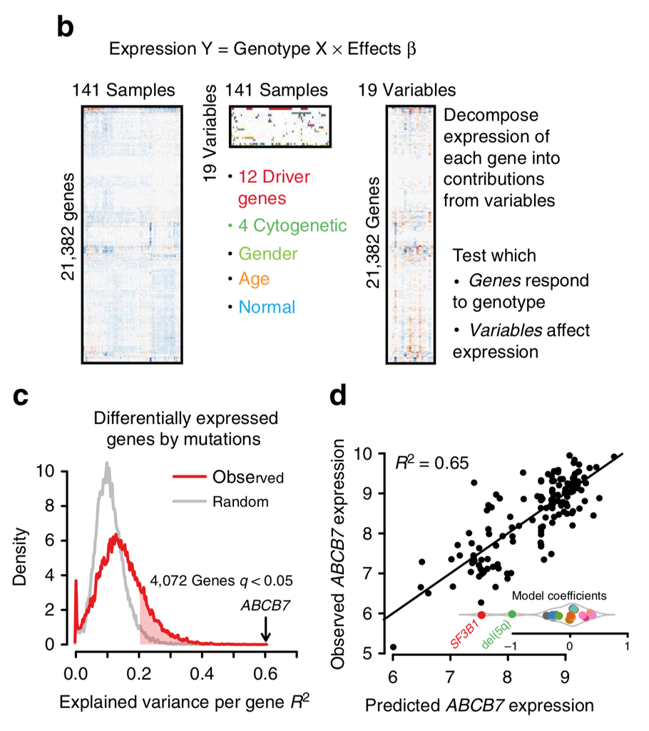

出自http://www.nature.com/articles/ncomms6901

fromhttp://www.nature.com/articles/ncomms6901

代码在原文补充材料中有提供，里面有很多东西值得学习。同时我自己写了一些比原文精简的代码（一些数据命名尽量和原文一致，确保小伙伴跑的时候能够理解不同做法的异曲同工）。

**小丫碎碎念：**像这种附带代码的好文章越来越多，是非常好的学习资源。

这类文章怎么找到呢？小丫的经验是：在感兴趣的期刊主页的高级搜索里，搜code或script，同时限定research article和发表年份等信息。检索结果里会有上下文，一眼扫过去，就能看到哪些文章带代码。

怎样学习这类代码？这次众筹就从这篇带代码的文章带你上手，以后你就可以自己去挖宝藏了。推荐路线：

- 先尝试自己写，或者至少在脑子里猜测作者是用什么方法哪个包实现的
- 看原文代码，边看边实践
- 记笔记，思考这段代码能应用到哪些场景上，可以尝试按照FigureYa的格式来写，或者干脆写成R包（Y叔说写R包要趁早）
- 用在自己的数据上，争取能用到paper里，经历了这一过程，你会有质的提升

自己死磕一篇文章的代码是孤独的，遇到问题也没人讨论，以后有机会我们可以搞个学习小组，感兴趣的小伙伴一起讨论同一篇文章的代码。

The code is provided in the supplementary materials of the original text, and there are many things worth learning from it. At the same time, I wrote some code that was more concise than the original text (some data names should be as consistent as possible with the original text to ensure that my friends can understand the similarities of different approaches when running).

**Xiaoya’s rambling: * * There are more and more good articles with accompanying code, which are very good learning resources.

How can I find such articles? Xiaoya’s experience is to search for code or script on the advanced search page of the journal she is interested in, while limiting information such as research article and publication year. There will be context in the search results, and at a glance, you can see which articles have code.

How to learn this type of code? This crowdfunding campaign will take you through this article with code, so you can dig for treasure on your own in the future. Recommended route:

-Try writing it yourself first, or at least guess in your mind what method and package the author used to implement it -Read the original code and practice while reading -Take notes and think about which scenarios this code can be applied to. You can try writing it in the format of FigureYa, or simply write it as an R package (Uncle Y said it’s better to write an R package as soon as possible) -Apply it to your own data and strive to use it in a paper. Through this process, you will have a qualitative improvement

It’s lonely to tinker with the code of an article by oneself, and no one will discuss it when encountering problems. In the future, we can form a study group where interested friends can discuss the code of the same article together.

## 应用场景

已有genotype和转录数据，通过线性模型解析突变对基因表达的贡献，即基因表达如何响应不同的genotype，不同的突变如何影响基因表达。

该模型的假设：

1. 每个突变位点只是影响特定的一些基因的表达；
2. 包含2种以上突变的个体，基因表达变化为两个或多个突变影响基因集合的并集；

缺点：该模型忽略了基因间的相互调控。

如果想要系统的研究基因之间的相互关系，就需要更多的基因样本容量，所以该线性模型方法是相对小样本量的很好的方式。

##Application scenarios

There is already genotype and transcription data available, and a linear model is used to analyze the contribution of mutations to gene expression, that is, how gene expression responds to different genotypes and how different mutations affect gene expression.

The assumption of this model is:

1. Each mutation site only affects the expression of specific genes;
2. Individuals with two or more mutations whose gene expression changes result in the union of gene sets affected by two or more mutations;

Disadvantage: This model ignores the mutual regulation between genes.

If you want to systematically study the interrelationships between genes, you need more gene sample sizes, so this linear model method is a good way for relatively small sample sizes.

## 环境设置

使用国内镜像安装包

##Environment settings

Use domestic image installation package

```r
options("repos"= c(CRAN="https://mirrors.tuna.tsinghua.edu.cn/CRAN/"))
options(BioC_mirror="http://mirrors.ustc.edu.cn/bioc/")
BiocManager::install("hgu133plus2.db")
```

加载包

library packages

```r
# 加载用于读取Excel文件的包
# Load the package for reading Excel files
library(openxlsx)
# 加载用于芯片数据处理的包
# Load the package for microarray data processing
library(affy)
# 加载用于芯片数据处理的包（GCRMA算法）
# Load the package for microarray data processing (GCRMA algorithm)
library(gcrma)
# 加载人类基因注释包
# Load the human gene annotation package
library(org.Hs.eg.db)
# 加载人类芯片(hgu133plus2)注释包
# Load the human microarray (hgu133plus2) annotation package
library(hgu133plus2.db)
# 加载线性模型分析包
# Load the package for linear model analysis
library(limma)
# 加载颜色方案包
# Load the package for color palettes
library(RColorBrewer)

# 设置环境变量，使R显示英文报错信息
# Set environment variable to display error messages in English
Sys.setenv(LANGUAGE = "en")
# 设置选项，禁止将字符串自动转换为因子类型
# Set option to prevent automatic conversion of strings to factors
options(stringsAsFactors = FALSE)
```

## 输入数据的预处理

需要两种输入数据：表达数据和基因型数据

表达数据：159个突变体和17个正常个体芯片数据，下载地址：< http://www.ncbi.nlm.nih.gov/geo/query/acc.cgi?acc=GSE58831>，点击Download里的http下载（早上下载速度更快），解压缩到当前文件夹。

genotype和表型数据：Supplementary Data 1—ncomms6901-s2.xlsx，其中部分个体数据缺失。

##Preprocessing of input data

Two types of input data are required: expression data and genotype data

Expression data: Chip data from 159 mutants and 17 normal individuals, download link:< http://www.ncbi.nlm.nih.gov/geo/query/acc.cgi?acc=GSE58831 >Click on the HTTP download in Download (faster download speed in the morning), and extract it to the current folder.

Genotype and phenotype data: Supplementary Data 1- ncomms6901-s2.xlsx, with some individual data missing.

### 芯片数据处理：

以下是芯片数据处理过程，主要用到affy，gcrma包

下面这一步需要较长的运行时间，我把运行结果gset保存在文件里，便于再次运行时读取

###Chip data processing:

The following is the chip data processing process, mainly using the affy and gcrma packages

The following step requires a relatively long running time. I will save the running result gset in a file for easy retrieval when running again

```r
celFiles <- dir("GSE58831_RAW",full.names=T)  #读取文件夹下面文件
affyBatch <- read.affybatch(filenames = celFiles)  #Read CEL files into an Affybatch
gset <- gcrma(affyBatch)  #converts an AffyBatch into an ExpressionSet
save(gset, file = "gset.RData")
```

```r
# 加载基因表达数据集   Load gene expression dataset
load("gset.RData")

# 处理样本名称，将格式为GSM1420467_MDS194.CEL.gz的样本名简化为GSM1420467
# Process sample names: simplify from format like GSM1420467_MDS194.CEL.gz to GSM1420467
samples <- sub("_.+","", sampleNames(gset))
sampleNames(gset) <- samples

# 将探针ID转换为ENTREZID（基因ID）
# Convert probe IDs to ENTREZIDs (gene IDs)
# 由于存在多个探针对应一个基因的情况（如1570001_at和222201_s_at均对应ENTREZID 9994），需对这些探针数据求平均值
# Note: Multiple probes may map to the same gene (e.g., 1570001_at and 222201_s_at both map to ENTREZID 9994), averaging their expression values is required
e <- exprs(gset)  # 提取表达矩阵  Extract expression matrix
e[1:3,1:3] # 查看表达矩阵前几行几列  View first few rows and columns of the matrix
```

```
##           GSM1420393 GSM1420394 GSM1420395
## 1007_s_at   4.440189   4.308577   4.308577
## 1053_at     8.899163   9.066933   9.594203
## 117_at      2.740344   3.450597   2.734854
```

```r
tab <- select(hgu133plus2.db, keys = keys(hgu133plus2.db), columns = c("ENTREZID"))   # 构建探针ID与ENTREZID的映射表  Build probe-to-gene mapping table
```

上面的e里面保存了探针组的表达矩阵，需要转换成ENTREZID对应的表达矩阵，这里提供三种方式，便于理解：

**方式一：**我自己用的code，比较繁琐，也容易理解。

思路是：在表达数据中加入ENTREZID，然后根据ENTREZID把dataframe通过split转换成list。之后把list中第一列的PROBEID和最后一列的ENTREZID去掉，最后通过sapply得到表达数据：

The expression matrix of the probe group is saved in the e above, which needs to be converted into the expression matrix corresponding to ENTREZID. Here are three ways to facilitate understanding:

**Method 1: * * The code I use myself is quite cumbersome and easy to understand.

The idea is to add ENTREZID to the expression data, and then convert the dataframe into a list through split based on ENTREZID. Afterwards, remove the PROBEID in the first column and ENTREZID in the last column of the list, and finally obtain the expression data through sapply:

```r
expr <- as.data.frame(e)
expr$PROBEID <- rownames(expr)
expr.id <- merge(expr,tab,by="PROBEID")
list <- split(expr.id, expr.id[,178])
list_new <- list
for (i in 1:length(list_new)){
list_new[[i]] <- list[[i]][,2:177]
}
geneExpr <- t(sapply(list_new,colMeans))
```

**方式二：**这是文章作者的代码，明显简洁许多，运行速度也快了很多，主要是在转换list这里节省了大量时间。

作者的思路是：首先把只含有PROBEID和ENTREZID两列数据按照ENTREZID转换成list，然后通过sapply加一个function就可以了:

**Method 2: * * This is the author’s code, which is obviously much simpler and runs much faster, mainly saving a lot of time in converting lists.

The author’s idea is to first convert the data containing only two columns, PROBEID and ENTREZID, into a list according to ENTREZID, and then add a function through sapply

```r
# 根据ENTREZID对探针分组，并计算每组探针表达值的均值，生成基因表达矩阵
# Group probes by ENTREZID and calculate the mean expression values for each gene, generating a gene expression matrix
geneExpr <- t(sapply(split(tab[,1], tab[,2]), function(ids){
                    colMeans(e[ids,,drop=FALSE])
                }))
```

**方式三：**如果以上理解有点困难，可以通过以下代码进行逐步操作，就会明白了：

**Method 3: * * If the above understanding is a bit difficult, you can gradually operate through the following code to understand:

```r
# 根据tab数据框的第二列对第一列进行分组，并存储为列表
# Split the first column of the 'tab' data frame by the second column and store as a list
list <- split(tab[,1], tab[,2])

# 定义一个函数，用于计算表达矩阵e中特定行(基因)的平均表达值
# Define a function to calculate the average expression values of specific rows (genes) in the expression matrix 'e'
colmean <- function(ids){
  colMeans(e[ids,,drop=FALSE])
}

# 对列表中的每个元素(基因集合)应用colmean函数，计算平均表达矩阵
# Apply the 'colmean' function to each element (gene set) in the list to calculate the average expression matrix
geneExpr1 <- sapply(list, colmean)

# 转置基因表达矩阵，使行代表样本，列代表基因集合
# Transpose the gene expression matrix so that rows represent samples and columns represent gene sets
geneExpr <- t(geneExpr1)
```

这里有一个小tip就是`e[ids,,drop=FALSE]`，一般来讲用中括号[]来提取大于一列时，得到的是matrix，但是提取某一列的时候一般得到的数据是vector，如果加上drop=FALSE参数，即使提取一列，同样也会得到matrix。

There is a small tip here, which is’ e [ids, drop=FALSE] ’. Generally speaking, when using parentheses [] to extract more than one column, the result is a matrix. However, when extracting a certain column, the data obtained is usually a vector. If the drop=False parameter is added, even if one column is extracted, the matrix will still be obtained.

### genotype突变信息

###Genotype mutation information

```r
# 从Excel文件中读取MDS数据，从第2行开始加载（跳过标题行）
# Read MDS data from an Excel file starting from row 2 (skipping the header)
mdsData <- read.xlsx("ncomms6901-s2.xlsx", startRow = 2, check.names = F)

# 查看数据前几行，了解数据结构
# View the first few rows of the data to understand its structure
head(mdsData)
```

```
##      PDID      GEOID                  File
## 1 PD6175a GSM1420393 GSM1420393_MDS009.CEL
## 2 PD6173a GSM1420394 GSM1420394_MDS011.CEL
## 3 PD6185a GSM1420395 GSM1420395_MDS012.CEL
## 4 PD6184a GSM1420396 GSM1420396_MDS014.CEL
## 5 PD6183a GSM1420397 GSM1420397_MDS015.CEL
## 6 PD6198a GSM1420398 GSM1420398_MDS025.CEL
##   Described.in.Papaemmanuil.et.al,.Blood.2013
## 1                                         yes
## 2                                         yes
## 3                                         yes
## 4                                         yes
## 5                                         yes
## 6                                         yes
##   Described.in.Pellagatti.et.al,.Leukemia.2010 Type Gender Age WHO_category
```

[output cut: 76 more lines]

```r
# 找出数据框中PDID列包含缺失值(NA)的行索引
# Find the row indices where the PDID column contains missing values (NA)
nu <- which(is.na(mdsData$PDID))

# 构建分析用的设计矩阵：移除PDID为NA的行（包括normal样本）
# 选择第27到79列、第7列和第90列作为分析变量
# Build the design matrix for analysis: remove rows with NA in PDID (including normal samples)
# Select columns 27 to 79, column 7, and column 90 as analysis variables
design <- mdsData[-nu, c(27:79, 7, 90)]

# 查看设计矩阵的前3行和前3列，确认数据结构
# View the first 3 rows and 3 columns of the design matrix to confirm data structure
design[1:3, 1:3]
```

```
##   SF3B1 TET2 SRSF2
## 1     0    0     0
## 2     0    0     0
## 3     0    0     0
```

把normal信息整合成起来，normal信息的所有突变基因列为0。定义年龄数据为NA：

Integrate the normal information and list all mutated genes in the normal information as 0. Define age data as NA:

```r
# 从mdsData中提取Normal样本，并选择分析所需的列(27:79,7,90)
# Extract Normal samples from mdsData and select columns for analysis (27:79,7,90)
normal <- mdsData[mdsData[,6]=="Normal", c(27:79,7,90)]

# 将Normal数据中的缺失值替换为0
# Replace missing values in Normal data with 0
normal[is.na(normal)] <- 0

# 初始化Normal样本的age_imp列为缺失值(后续可能用于年龄插补)
# Initialize age_imp column for Normal samples as NA (to be imputed later)
normal$age_imp <- NA

# 将处理后的突变样本(design)与正常样本(normal)合并
# Combine processed mutant samples (design) with normal samples (normal)
design <- rbind(design, normal)

# 根据基因7503的表达水平推断Normal样本的性别(表达>5为男性)
# Infer gender of Normal samples based on expression of gene 7503 (expression >5 indicates male)
design[125:141, "Gender"] <- geneExpr["7503", as.character(mdsData[mdsData[,6]=="Normal", 2])] > 5

# 筛选至少在5个样本中出现的特征(过滤低频特征)
# Filter features present in at least 5 samples (remove rare features)
design <- design[, colSums(design, na.rm=T) >= 5]

# 添加Normal列标记样本类型(0=突变样本,1=正常样本)
# Add Normal column to indicate sample type (0=mutant, 1=normal)
design$Normal <- c(rep(0, nrow(design)-nrow(normal)), rep(1, nrow(normal)))

# 添加offset列作为模型偏移项(通常设为1)
# Add offset column for modeling purposes (typically set to 1)
design$offset <- 1

# 重新排列列顺序以优化分析
# Rearrange column order for analysis
design <- design[, c(20, 1:16, 19, 17:18)]

# 对age_imp列进行中心化处理(减去均值)
# Center the age_imp column (subtract mean)
design$age_imp <- scale(design$age_imp, center=T, scale=F)

# 设置行名为样本ID
# Set row names to sample IDs
rownames(design) <- c(as.character(mdsData[-nu, 2]), as.character(mdsData[mdsData[,6]=="Normal", 2]))

# 用列均值填充缺失值(常见的数据预处理步骤)
# Fill missing values with column means (common data preprocessing step)
for(j in 1:ncol(design))
    design[is.na(design[,j]), j] <- mean(design[,j], na.rm=TRUE)

# 查看处理后的设计矩阵前几行
# View the first few rows of the processed design matrix
head(design)
```

```
##            offset SF3B1 TET2 SRSF2 ASXL1 DNMT3A RUNX1 U2AF1 TP53 EZH2 STAG2
## GSM1420393      1     0    0     0     0      0     0     0    0    0     0
## GSM1420394      1     0    0     0     0      0     0     1    0    0     0
## GSM1420395      1     0    0     0     0      0     0     0    0    0     0
## GSM1420396      1     0    0     0     0      0     0     0    0    0     0
## GSM1420397      1     0    0     0     1      0     0     0    0    0     0
## GSM1420398      1     0    0     0     0      0     0     0    0    0     0
##            ZRSR2 JAK2 del(5q) tri(8) del(12p) del(20q) Normal Gender   age_imp
## GSM1420393     0    0       1      0        0        0      0      1  10.58871
## GSM1420394     0    0       1      0        0        0      0      1  -4.41129
## GSM1420395     0    0       1      0        0        0      0      1 -15.41129
## GSM1420396     0    1       1      0        0        0      0      1 -23.41129
## GSM1420397     0    0       1      0        0        0      0      1 -14.41129
## GSM1420398     0    0       0      0        0        0      0      0  -4.41129
```

## 构建线性模型

这里主要用到limma包，其中F.stat，是F-statistic检验，该值越大，一般p值越小，即差异显著。

##Constructing a linear model

The limma package is mainly used here, where F.stat is the F-statistical test. The larger the value, the smaller the p-value, indicating a significant difference.

```r
# 使用limma包的lmFit函数拟合线性模型，分析基因表达数据与设计矩阵的关系
# Fit a linear model using limma's lmFit function to analyze the relationship between gene expression and design matrix
glm <- lmFit(geneExpr[, rownames(design)], design = design)

# 使用eBayes函数对线性模型的结果进行经验贝叶斯调节，提高统计检验的稳定性
# Apply empirical Bayes moderation to the linear model results using eBayes to improve statistical testing stability
glm <- eBayes(glm)

# 计算F统计量，用于评估多个变量对基因表达的联合效应
# F.stat包含每个基因的F统计量值，用于后续的差异表达基因筛选
# Calculate F-statistics to evaluate the joint effect of multiple variables on gene expression
# F.stat contains F-statistic values for each gene, used for subsequent differential expression gene screening
F.stat <- classifyTestsF(glm[,-1], fstat.only = TRUE)
```

## 开始画图-b

b图里有三个小图，我们分别来画。

定义颜色，主要定义19种颜色，每种颜色在之后会代表每一个design的列信息：

##Start drawing - b

There are three small pictures in Figure B, let’s draw them separately.

Define colors, mainly 19 colors, each representing column information for each design:

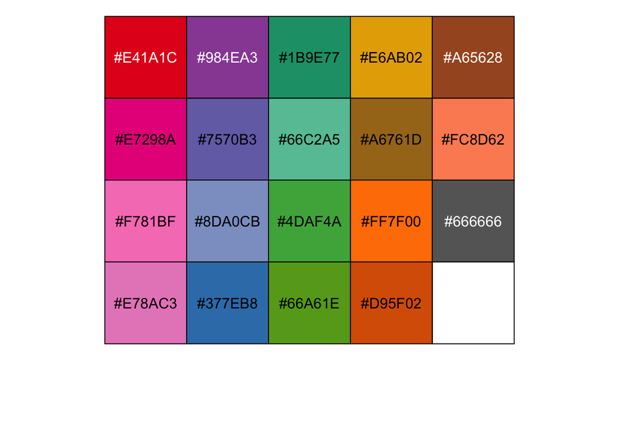

```r
# 从RColorBrewer包中创建一个包含多种颜色的向量，用于可视化不同突变类型
# Create a color vector from RColorBrewer for visualizing different mutation types
colMutations <- c(brewer.pal(8, "Set1")[-6], rev(brewer.pal(8, "Dark2")), brewer.pal(7, "Set2"))[c(1:12, 16:19, 13:15)]

# 根据颜色的色相(Hue)对颜色向量进行排序
# Sort the color vector by hue for better visual grouping
o <- order(apply(col2rgb(colMutations), 2, rgb2hsv)[1, ])

# 反转排序顺序并重新排列颜色，创建更美观的颜色循环
# Reverse the order and reposition colors to create a visually appealing cycle
colMutations <- colMutations[rev(o)][(4*1:19 + 15) %% 19 + 1]

# 为颜色向量命名，使其与设计矩阵中的列名(突变类型)对应
# Name the colors to match the column names (mutation types) in the design matrix
names(colMutations) <- colnames(design)[-1]

# 加载scales包用于颜色显示
# Load the scales package for color visualization
library("scales")

# 显示颜色方案，帮助用户预览用于后续图表的颜色
# Display the color palette for preview before using in plots
show_col(colMutations)
```

选取Fstat最大的前1000个基因用于作图

Select the top 1000 genes with the highest Fstat for mapping

```r
# 选择F统计量最高的前1000个基因，按降序排列并提取基因名称
# Select the top 1000 genes with the highest F-statistics, sorted in descending order, and extract gene names
w <- names(sort(F.stat, decreasing = TRUE)[1:1000])

# 从设计矩阵中移除第一列(通常是截距项)，保留突变类型相关的列
# Remove the first column (usually the intercept term) from the design matrix, retaining mutation type columns
z <- design[,-1]

# 筛选基因表达矩阵，仅保留设计矩阵中存在的样本对应的列
# Filter the gene expression matrix to include only columns (samples) present in the design matrix
geneExpr <- geneExpr[, rownames(design)]
```